# Labelr - A Selective Introduction

## A Whirlwind Tour

This vignette provides an ad hoc introduction to a smattering of labelr functionalities and uses cases. Other brief vignettes cover additional issues and applications, offering a mix of new material and expanded treatments or excerpts from this vignette.

## Types of Labels

labelr supports the creation and use of a few different types of labels in the context of R data.frames. Specifically, labelr supports three core types of data.frame labels, the last of which comes in three flavors:

1. **Frame labels** - Each data.frame may be given a single “frame label” of 500 characters or fewer, which may describe key general features or characteristics of the data set (e.g., source, date produced or published, high-level contents).
2. **Name labels** - Each variable may be given exactly one name label, which is an extended variable name or brief description of the variable. For example, if a variable called “st_b” refers to a survey respondent’s state of birth, then a sensible and useful name label might be “State of Birth”. Or, if a variable called “trust1” consisted of responses to the consumer survey question, “How much do you trust BBC news to give you unbiased information?,” a sensible name label might be “BBC Trust.” As such, name labels are comparable to what Stata and SAS call “variable labels.”
3. **Value labels** - labelr offers three kinds of value labels.
   - *One-to-one labels* - The canonical value-labeling use case entails mapping distinct values of a variable to distinct labels in a one-to-one fashion, so that each value label uniquely identifies a substantive value. For instance, an administrative data set might assign the integers 1-7 to seven distinct racial/ethnic groups, and value labels would be critical in mapping those numbers to socially substantive racial/ethnic category concepts (e.g., Which number corresponds to the “Asian American?”).
   - *Many-to-one labels* - In an alternative use case, value labels may serve to distill or “bucket” distinct variable values in a way that deliberately “throws away” information for purposes of simplification. For example, one may wish to give the single label “Agree” to the responses “Very Strongly Agree,” “Strongly Agree,” and “Agree.” Or one may wish to differentiate self-identified “White” respondents from “People of Color,” applying the latter value label to all categories other than “White.”
   - *Numerical range labels* - Finally, one may wish to carve a numerical variable into an ordinal or qualitative range, such as dichotomizing a variable or dividing it into quantiles. Numerical range labels support one-to-many assignment of a single value label to a range of numerical values for a given variable.

## Core Use Cases and Capabilities

More specifically, labelr functions support the following actions:

1. Assigning variable value labels, name labels, and a frame label to data.frames and modifying those labels thereafter.
2. Generating and accessing simple look-up table-style data.frames to inform or remind you about a given variable’s name label, frame label, or the value labels that correspond to its unique values (i.e., Which racial/ethnic identity category label corresponds to a value of 3?).
3. Swapping out variable names for variable labels and back again.
4. Replacing variables’ values with their corresponding labels.
5. Augmenting a data.frame by adding columns of variable labels that can exist alongside the column of variable values.
6. Engaging in base::subset-like row-filtering, using value labels to guide the filtering without converting values to labels in the returned data.frame.
7. Tabulating value frequencies that can be expressed in terms of raw values or value labels– again, without modifying or converting the raw data.frame values.
8. Preserving and restoring a data.frame’s labelr labels in the event that some unsupported R operation destroys them.
9. Applying a single value-labeling scheme to many variables at once (for example, assigning the same set of Likert-scale labels (“Strongly Agree,” etc.) to all variables that share a common variable name character substring.

## Load the Package

Let’s start by loading labelr.

```r
library(labelr)
```

## Demonstration 1 - (Fake) Demographic Data

Let’s create a fake “demographic” data.frame, apply labels to it, and do some things with those labels.

### Make toy demographic data.frame

This function (included with labelr) creates fake “demographic” data intended for use in exploring/demonstrating labelr functionality.

```r
set.seed(555)
df <- make_demo_data(n = 1000)
```

### Add a variable “frame label” using `add_frame_lab()`

We’ll start our labeling session by providing a fittingly fictional high-level description of this fictional data set.

```r
df <- add_frame_lab(df, frame.lab = "Demographic and reaction time test score
                    records collected by Royal Statistical Agency of
                    Fictionaslaviaca. Data fictionally collected in the year
                    1987. As published in A. Smithee (1988). Some Fictional Data
                    for Your Amusement. Mad Magazine, 10(1), 1-24.")


get_frame_lab(df)
### >   data.frame
### > 1         df
### >                                                                                                                                                                                                                                                        frame.lab
### > 1 Demographic and reaction time test score records collected by Royal Statistical Agency of Fictionaslaviaca. Data fictionally collected in the year 1987. As published in A. Smithee (1988). Some Fictional Data for Your Amusement. Mad Magazine, 10(1), 1-24.
```

### Add variable name labels using `add_name_labs()`

Now, let’s add (some fairly trivial) variable NAME labels

```r
df <- add_name_labs(df, name.labs = c(
  "age" = "Age in years",
  "raceth" = "Racial/ethnic identity group category",
  "gender" = "Gender identity",
  "edu" = "Highest education level attained",
  "x1" = "Space Invaders reaction time test scores",
  "x2" = "Galaga reaction time test scores"
))
```

Even if we do nothing else with these name labels, we can access or manipulate a simple lookup table as needed.

```r
get_name_labs(df)
### >      var                                      lab
### > 1     id                                       id
### > 2    age                             Age in years
### > 3 gender                          Gender identity
### > 4 raceth    Racial/ethnic identity group category
### > 5    edu         Highest education level attained
### > 6     x1 Space Invaders reaction time test scores
### > 7     x2         Galaga reaction time test scores
```

### Add value labels using `add_val_labs()`

Let’s add one-to-one value labels for variable “raceth”. Note: max.unique.vals sets an upper limit on the number of unique values a variable may have be considered “value-label-able.” labelr sets an overall upper limit of 5000 unique value labels permissible per variable.

```r
df <- add_val_labs(df,
  vars = "raceth", vals = c(1:7),
  labs = c(
    "White", "Black", "Hispanic",
    "Asian", "AIAN", "Multi", "Other"
  ),
  max.unique.vals = 10
)
### > Labeling variable --raceth--:
### >      var vals     labs
### > 1 raceth    1    White
### > 2 raceth    2    Black
### > 3 raceth    3 Hispanic
### > 4 raceth    4    Asian
### > 5 raceth    5     AIAN
### > 6 raceth    6    Multi
### > 7 raceth    7    Other
### > 8 raceth   NA       NA
```

### Add value labels using `add_val1()`

Let’s add value labels for variable “gender.” Function `add_val1` allows you to supply the variable name unquoted, provided you are value-labeling only one variable. (Not evident from the above, but add_val_labs supports labeling multiple variables at once).

```r
df <- add_val1(
  data = df, gender, vals = c(0, 1, 2),
  labs = c("Male", "Female", "Other"), max.unique.vals = 10
)
### > Labeling variable --gender--:
### >       var vals   labs
### > 9  gender    0   Male
### > 10 gender    1 Female
### > 11 gender    2  Other
### > 12 gender   NA     NA
```

Once again, we can create a lookup table with the labels-to-values mappings.

```r
get_val_labs(df)
### >       var vals     labs
### > 1  gender    0     Male
### > 2  gender    1   Female
### > 3  gender    2    Other
### > 4  gender   NA       NA
### > 5  raceth    1    White
### > 6  raceth    2    Black
### > 7  raceth    3 Hispanic
### > 8  raceth    4    Asian
### > 9  raceth    5     AIAN
### > 10 raceth    6    Multi
### > 11 raceth    7    Other
### > 12 raceth   NA       NA
```

### Add NUMERICAL RANGE Labels Using `add_quant_labs()`

Traditionally, value labels are intended for categorical variables, such as binary, nominal, or (integer) ordinal variables with limited numbers of distinct categories. Further, value labels that are added using `add_val_labs` (or `add_val1`) are constrained to map one-to-one to distinct values: Any given value label can map to only one distinct value and vice versa.

If you wish to apply a label to a range of values of a numerical variable, such as labeling each value according to the quintile or decile to which it belongs, you can use `add_quant_labs()` (or `add_quant1`) to do so.

Here, we will use `add_quant_labs` to apply quintile range labels to all variables of df that have an “x” in their names (i.e., vars “x1” and “x2”)

```r
df_temp <- add_quant_labs(data = df, vars = "x", qtiles = 5, partial = TRUE)
### > Labeling variable --x1--:
### >    var    vals labs
### > 13  x1  82.976 q020
### > 14  x1  95.238 q040
### > 15  x1 106.142 q060
### > 16  x1 117.524 q080
### > 17  x1  157.98 q100
### > 18  x1      NA   NA
### > Labeling variable --x2--:
### >    var    vals labs
### > 19  x2 0.22404 q020
### > 20  x2 0.41608 q040
### > 21  x2 0.62034 q060
### > 22  x2 0.80538 q080
### > 23  x2  0.9992 q100
### > 24  x2      NA   NA
### > Remember: This command uses partial vars arg matching.
### > Use a more specific vars argument or set partial = FALSE
### > ...if you want to restrict labeling to fewer/more specific variables.
```

As `add_quant_labs` adds those numerical range labels, the console output shows the actual quintile value of the supplied variable (here, “x1” and “x2”) that corresponds to each quintile (range) label. Any value at or below that value (and above the next-lowest quintile value) is assigned that quintile label.

We can use the same function to assign arbitrary, user-specified range labels. Here, we assign labels that differentiate values of “x1” and “x2” that are at or below 100 from values that are at or below 150.

```r
df_temp <- add_quant_labs(
  data = df_temp, vars = "x", vals = c(100, 150),
  partial = TRUE
)
### >
### >   Dropping all value labels from variable --x1--.
### > Labeling variable --x1--:
### >    var vals  labs
### > 19  x1  100 <=100
### > 20  x1  150 <=150
### > 21  x1   NA    NA
### >
### >   Dropping all value labels from variable --x2--.
### > Warning in add_quant_labs(data = df_temp, vars = "x", vals = c(100, 150), :
### >
### > Some of the supplied vals argument values are outside
### > the observed range of var --x2-- values
### > Labeling variable --x2--:
### >    var vals  labs
### > 16  x2  100 <=100
### > 17  x2  150 <=150
### > 18  x2   NA    NA
### > Remember: This command uses partial vars arg matching.
### > Use a more specific vars argument or set partial = FALSE
### > ...if you want to restrict labeling to fewer/more specific variables.
```

```r
df <- add_quant1(df, x1, qtiles = 5)
### > Labeling variable --x1--:
### >    var    vals labs
### > 13  x1  82.976 q020
### > 14  x1  95.238 q040
### > 15  x1 106.142 q060
### > 16  x1 117.524 q080
### > 17  x1  157.98 q100
### > 18  x1      NA   NA
```

We’ll preserve the “x1” range labels going forward, keeping “x2” unlabeled.

### Add MANY-TO-ONE VALUE Labels Using `add_m1_lab()`

If you wish to apply a single label to multiple distinct values, this can be done through successive calls to `add_m1_lab()` (or `add1m1()`, if working with a single variable). Here “m1” is shorthand for “many to one.”

Note that each call to `add_m1_lab()` applies a single value label, so,  
multiple calls are needed to apply multiple labels. Here, we illustrate this, applying the label “Some College+” to values 3, 4, or 5 of the variable “edu”, then applying other distinct labels to values 1 and 2, respectively.

```r
df <- add_m1_lab(df, "edu", vals = c(3:5), lab = "Some College+")
### > Labeling variable --edu--:
### >    var vals          labs
### > 19 edu    1             1
### > 20 edu    2             2
### > 21 edu    3 Some College+
### > 22 edu    4 Some College+
### > 23 edu    5 Some College+
### > 24 edu   NA            NA

df <- add_m1_lab(df, "edu", vals = 1, lab = "Not HS Grad")
### > Labeling variable --edu--:
### >    var vals          labs
### > 13 edu    1   Not HS Grad
### > 14 edu    2             2
### > 15 edu    3 Some College+
### > 16 edu    4 Some College+
### > 17 edu    5 Some College+
### > 18 edu   NA            NA

df <- add_m1_lab(df, "edu", vals = 2, lab = "HSG, No College")
### > Labeling variable --edu--:
### >    var vals            labs
### > 13 edu    1     Not HS Grad
### > 14 edu    2 HSG, No College
### > 15 edu    3   Some College+
### > 16 edu    4   Some College+
### > 17 edu    5   Some College+
### > 18 edu   NA              NA

get_val_labs(df)
### >       var    vals            labs
### > 1  gender       0            Male
### > 2  gender       1          Female
### > 3  gender       2           Other
### > 4  gender      NA              NA
### > 5  raceth       1           White
### > 6  raceth       2           Black
### > 7  raceth       3        Hispanic
### > 8  raceth       4           Asian
### > 9  raceth       5            AIAN
### > 10 raceth       6           Multi
### > 11 raceth       7           Other
### > 12 raceth      NA              NA
### > 13    edu       1     Not HS Grad
### > 14    edu       2 HSG, No College
### > 15    edu       3   Some College+
### > 16    edu       4   Some College+
### > 17    edu       5   Some College+
### > 18    edu      NA              NA
### > 19     x1  82.976            q020
### > 20     x1  95.238            q040
### > 21     x1 106.142            q060
### > 22     x1 117.524            q080
### > 23     x1  157.98            q100
### > 24     x1      NA              NA
```

### Where Do We Stand?

All of this is nice, but have we really accomplished anything? A casual view of the data.frame suggests that it has not changed from its initial state.

```r
head(df)
### >     id age gender raceth edu     x1     x2
### > T-1  1  59      1      4   5 120.25 0.5928
### > N-2  2  56      1      1   2  67.12 0.9116
### > D-3  3  54      1      6   3  79.28 0.6993
### > Q-4  4  46      1      5   4  99.59 0.2243
### > E-5  5  18      1      6   4  90.49 0.0099
### > K-6  6  45      0      2   4  78.55 0.9250
```

But labeling has introduced unobtrusive but important features for us to use. Let’s take a look.

### Swap out values for labels with `use_val_labs()` and `with_*()` commands

Now that our data.frame is labeled, we can overlay value labels – that is, swap out values for labels. We might do this temporarily, to visualize the labels.

```r
head(use_val_labs(df), 5)
### >     id age gender raceth             edu   x1     x2
### > T-1  1  59 Female  Asian   Some College+ q100 0.5928
### > N-2  2  56 Female  White HSG, No College q020 0.9116
### > D-3  3  54 Female  Multi   Some College+ q020 0.6993
### > Q-4  4  46 Female   AIAN   Some College+ q060 0.2243
### > E-5  5  18 Female  Multi   Some College+ q040 0.0099
```

Or we could do something more “permanent,” such as assigning the result to a new object that will replace our value-labeled columns. There is no direct way to “undo” a call to `use_val_labs()`, so, it is safest to assign the result to a new object (or try `add_lab_cols()`, discusse momentarily).

```r
df_labd <- use_val_labs(df)
```

Similarly, we can use with()-like non-standard evaluation to overlay labels, which is helpful in a few limited cases. Note how `with_val_labs` behaves below.

```r
with(df, table(gender, raceth))
### >       raceth
### > gender  1  2  3  4  5  6  7
### >      0 83 66 62 65 64 68 61
### >      1 70 74 79 56 83 69 64
### >      2  3  7  3  6  8  3  6

with_val_labs(df, table(gender, raceth))
### >         raceth
### > gender   AIAN Asian Black Hispanic Multi Other White
### >   Female   83    56    74       79    69    64    70
### >   Male     64    65    66       62    68    61    83
### >   Other     8     6     7        3     3     6     3

wvl(df, table(gender, raceth)) # wvl() is an more compact alias
### >         raceth
### > gender   AIAN Asian Black Hispanic Multi Other White
### >   Female   83    56    74       79    69    64    70
### >   Male     64    65    66       62    68    61    83
### >   Other     8     6     7        3     3     6     3

with(use_val_labs(df), table(gender, raceth))
### >         raceth
### > gender   AIAN Asian Black Hispanic Multi Other White
### >   Female   83    56    74       79    69    64    70
### >   Male     64    65    66       62    68    61    83
### >   Other     8     6     7        3     3     6     3
```

We also have options for overlaying / swapping out variable NAME labels for actual variable column names, as we’ll see below.

### Show First, Last, or Random Rows with Value Labels Overlaid

Base R includes the `head()` and `tail()` functions, which allow you to show the first n or last n rows of a data.frame. The car package offers a similar function called `some()`, which allows you to show a random n rows of a data.frame.

labelr provides versions of these functions that will display value labels in place of values (akin to `use_val_labs()`). Below, each of the three standard functions is demonstrated, followed by its labelr counterpart.

```r
head(df, 5) # Base R function utils::head()
### >     id age gender raceth edu     x1     x2
### > T-1  1  59      1      4   5 120.25 0.5928
### > N-2  2  56      1      1   2  67.12 0.9116
### > D-3  3  54      1      6   3  79.28 0.6993
### > Q-4  4  46      1      5   4  99.59 0.2243
### > E-5  5  18      1      6   4  90.49 0.0099

headl(df, 5) # labelr function headl() (note the "l")
### >     id age gender raceth             edu   x1     x2
### > T-1  1  59 Female  Asian   Some College+ q100 0.5928
### > N-2  2  56 Female  White HSG, No College q020 0.9116
### > D-3  3  54 Female  Multi   Some College+ q020 0.6993
### > Q-4  4  46 Female   AIAN   Some College+ q060 0.2243
### > E-5  5  18 Female  Multi   Some College+ q040 0.0099

tail(df, 5) # Base R function utils::tail()
### >          id age gender raceth edu     x1     x2
### > Z-996   996  63      0      1   4  92.36 0.0447
### > S-997   997  18      0      4   4 147.40 0.2252
### > K-998   998  45      0      5   2 106.87 0.1610
### > I-999   999  46      1      4   2 119.13 0.7666
### > H-1000 1000  68      0      6   5  70.38 0.5123

taill(df, 5) # labelr function taill() (note the "l")
### >          id age gender raceth             edu   x1     x2
### > Z-996   996  63   Male  White   Some College+ q040 0.0447
### > S-997   997  18   Male  Asian   Some College+ q100 0.2252
### > K-998   998  45   Male   AIAN HSG, No College q080 0.1610
### > I-999   999  46 Female  Asian HSG, No College q100 0.7666
### > H-1000 1000  68   Male  Multi   Some College+ q020 0.5123

car::some(df, 5) # car package function car::some()
### >        id age gender raceth edu     x1     x2
### > H-89   89  24      0      3   3 110.56 0.9992
### > W-425 425  52      1      4   5 108.73 0.0726
### > W-663 663  29      0      6   3  75.43 0.8891
### > M-743 743  28      1      1   4 107.95 0.4214
### > P-983 983  31      0      7   2 111.65 0.8703

somel(df, 5, seed = 1837) # labelr function somel() (note the "l")
### >        id age gender   raceth             edu   x1     x2
### > B-407 407  45 Female Hispanic   Some College+ q020 0.3781
### > O-634 634  33   Male    Asian   Some College+ q060 0.9275
### > F-893 893  56   Male    White   Some College+ q080 0.9966
### > S-361 361  53 Female    Asian HSG, No College q020 0.5263
### > K-452 452  40   Male Hispanic   Some College+ q100 0.3242
```

Note that `some()` and `somel()` will not return the same random rows.

### Add value labels back to the data.frame with `add_lab_cols()`

Whereas `use_val_labs()` replaces value-labeled variable values with their labels, we do not strictly need to choose between values and labels. We can preserve all existing variables, including the value-labeled ones, while adding an additional labels-as-values column for each value-labeled column. Easier done than said, perhaps. Take a look:

```r
df_plus_labs <- add_lab_cols(df)

head(df_plus_labs)
### >     id age gender raceth edu     x1     x2 gender_lab raceth_lab
### > T-1  1  59      1      4   5 120.25 0.5928     Female      Asian
### > N-2  2  56      1      1   2  67.12 0.9116     Female      White
### > D-3  3  54      1      6   3  79.28 0.6993     Female      Multi
### > Q-4  4  46      1      5   4  99.59 0.2243     Female       AIAN
### > E-5  5  18      1      6   4  90.49 0.0099     Female      Multi
### > K-6  6  45      0      2   4  78.55 0.9250       Male      Black
### >             edu_lab x1_lab
### > T-1   Some College+   q100
### > N-2 HSG, No College   q020
### > D-3   Some College+   q020
### > Q-4   Some College+   q060
### > E-5   Some College+   q040
### > K-6   Some College+   q020

head(df_plus_labs[c("gender", "gender_lab", "raceth", "raceth_lab")])
### >     gender gender_lab raceth raceth_lab
### > T-1      1     Female      4      Asian
### > N-2      1     Female      1      White
### > D-3      1     Female      6      Multi
### > Q-4      1     Female      5       AIAN
### > E-5      1     Female      6      Multi
### > K-6      0       Male      2      Black
```

### “Filter values using labels” with `flab()`

We can filter a value-labeled data.frame on the basis for value labels, returning the subsetted data.frame with the labels still in the background. For example, here we use the more semantically meaningful value labels to filter our data.frame.

```r
head(df)
### >     id age gender raceth edu     x1     x2
### > T-1  1  59      1      4   5 120.25 0.5928
### > N-2  2  56      1      1   2  67.12 0.9116
### > D-3  3  54      1      6   3  79.28 0.6993
### > Q-4  4  46      1      5   4  99.59 0.2243
### > E-5  5  18      1      6   4  90.49 0.0099
### > K-6  6  45      0      2   4  78.55 0.9250

df1 <- flab(df, raceth == "Asian" & gender == "Female")
### >
### > Remember: Any filtering conditions involving value-labeled variables must be expressed
### > in terms of the (quoted character) value labels, not the variable values themselves.
### >
### > To filter using values (not labels) of value-labeled variables, try, e.g., sfilter().

head(df1, 5)
### >      id age gender raceth edu     x1     x2
### > T-1   1  59      1      4   5 120.25 0.5928
### > D-40 40  60      1      4   4  78.12 0.9885
### > E-67 67  39      1      4   5  98.21 0.6244
### > I-73 73  36      1      4   2  98.42 0.2102
### > V-80 80  27      1      4   4 122.62 0.3137

head(use_val_labs(df1), 5)
### >      id age gender raceth             edu   x1     x2
### > T-1   1  59 Female  Asian   Some College+ q100 0.5928
### > D-40 40  60 Female  Asian   Some College+ q020 0.9885
### > E-67 67  39 Female  Asian   Some College+ q060 0.6244
### > I-73 73  36 Female  Asian HSG, No College q060 0.2102
### > V-80 80  27 Female  Asian   Some College+ q100 0.3137
```

### “Subset using labels” with `slab()`

As with `base::subset()`, we can also limit which columns we return.

```r
head(slab(df, raceth == "Black" & gender == "Male", gender, raceth), 10)
### >
### > Remember: Any slab() filtering conditions involving value-labeled variables must be expressed
### > in terms of the (quoted character) value labels, not the variable values themselves.
### >
### > To filter using values (not labels) of value-labeled variables, try, e.g., ssubset().
### >       gender raceth
### > K-6        0      2
### > F-22       0      2
### > E-30       0      2
### > O-46       0      2
### > Q-48       0      2
### > F-72       0      2
### > T-117      0      2
### > K-149      0      2
### > M-161      0      2
### > A-167      0      2
```

### Tabulate frequencies with `tabl()`

labelr’s `tabl()` function supports count tabulations with labels turned “on” or “off” and offers some other functionalities. For example, tables can be generated…

…in terms of values

```r
head(tabl(df), 20)
### >
### > Excluding variable --id-- (includes decimals or exceeds max.unique.vals).
### >
### > Excluding variable --age-- (includes decimals or exceeds max.unique.vals).
### >
### > Excluding variable --x1-- (includes decimals or exceeds max.unique.vals).
### >
### > Excluding variable --x2-- (includes decimals or exceeds max.unique.vals).
### >
### > Note: To filter zero-frequency rows (i.e., un-observed value combinations)
### > set zero.rm = TRUE.
### >    gender raceth edu  n
### > 1       1      2   2 29
### > 2       0      1   3 28
### > 3       1      1   2 28
### > 4       1      5   2 27
### > 5       1      5   3 26
### > 6       1      6   2 26
### > 7       1      7   2 25
### > 8       1      3   3 24
### > 9       0      2   3 23
### > 10      0      4   2 23
### > 11      0      5   2 23
### > 12      0      1   2 22
### > 13      0      3   3 22
### > 14      0      6   3 22
### > 15      1      3   4 22
### > 16      0      1   4 21
### > 17      0      2   2 21
### > 18      1      2   3 21
### > 19      1      3   2 21
### > 20      0      6   2 20
```

…or in terms of labels

```r
head(tabl(df, labs.on = TRUE), 20)
### >
### > Excluding variable --id-- (includes decimals or exceeds max.unique.vals).
### >
### > Excluding variable --age-- (includes decimals or exceeds max.unique.vals).
### >
### > Excluding variable --x2-- (includes decimals or exceeds max.unique.vals).
### >
### > Note: To filter zero-frequency rows (i.e., un-observed value combinations)
### > set zero.rm = TRUE.
### >    gender   raceth           edu   x1  n
### > 1    Male    Other Some College+ q020 18
### > 2    Male    White Some College+ q020 14
### > 3    Male    White Some College+ q060 14
### > 4  Female     AIAN Some College+ q020 13
### > 5  Female     AIAN Some College+ q060 13
### > 6  Female Hispanic Some College+ q040 13
### > 7  Female Hispanic Some College+ q100 13
### > 8    Male     AIAN Some College+ q040 13
### > 9  Female     AIAN Some College+ q080 12
### > 10 Female    Asian Some College+ q080 12
### > 11 Female    Black Some College+ q060 12
### > 12   Male    Multi Some College+ q020 12
### > 13   Male    Multi Some College+ q100 12
### > 14   Male    White Some College+ q080 12
### > 15 Female Hispanic Some College+ q020 11
### > 16 Female    White Some College+ q080 11
### > 17   Male    Asian Some College+ q040 11
### > 18   Male    Black Some College+ q040 11
### > 19   Male Hispanic Some College+ q100 11
### > 20 Female     AIAN Some College+ q040 10
```

…in proportions

```r
head(tabl(df, labs.on = TRUE, prop.digits = 3), 20)
### >
### > Excluding variable --id-- (includes decimals or exceeds max.unique.vals).
### >
### > Excluding variable --age-- (includes decimals or exceeds max.unique.vals).
### >
### > Excluding variable --x2-- (includes decimals or exceeds max.unique.vals).
### >
### > Note: To filter zero-frequency rows (i.e., un-observed value combinations)
### > set zero.rm = TRUE.
### >    gender   raceth           edu   x1     n
### > 1    Male    Other Some College+ q020 0.018
### > 2    Male    White Some College+ q020 0.014
### > 3    Male    White Some College+ q060 0.014
### > 4  Female     AIAN Some College+ q020 0.013
### > 5  Female     AIAN Some College+ q060 0.013
### > 6  Female Hispanic Some College+ q040 0.013
### > 7  Female Hispanic Some College+ q100 0.013
### > 8    Male     AIAN Some College+ q040 0.013
### > 9  Female     AIAN Some College+ q080 0.012
### > 10 Female    Asian Some College+ q080 0.012
### > 11 Female    Black Some College+ q060 0.012
### > 12   Male    Multi Some College+ q020 0.012
### > 13   Male    Multi Some College+ q100 0.012
### > 14   Male    White Some College+ q080 0.012
### > 15 Female Hispanic Some College+ q020 0.011
### > 16 Female    White Some College+ q080 0.011
### > 17   Male    Asian Some College+ q040 0.011
### > 18   Male    Black Some College+ q040 0.011
### > 19   Male Hispanic Some College+ q100 0.011
### > 20 Female     AIAN Some College+ q040 0.010
```

…cross-tab style

```r
head(tabl(df, labs.on = TRUE, wide.col = "gender"), 20)
### >
### > Excluding variable --id-- (includes decimals or exceeds max.unique.vals).
### >
### > Excluding variable --age-- (includes decimals or exceeds max.unique.vals).
### >
### > Excluding variable --x2-- (includes decimals or exceeds max.unique.vals).
### >
### > Note: To filter zero-frequency rows (i.e., un-observed value combinations)
### > set zero.rm = TRUE.
### >      raceth           edu   x1 Male Female Other
### > 1     Other Some College+ q020   18      5     1
### > 2     White Some College+ q020   14      5     0
### > 3     White Some College+ q060   14      5     2
### > 4      AIAN Some College+ q020    6     13     1
### > 5      AIAN Some College+ q060    8     13     0
### > 6  Hispanic Some College+ q040    8     13     0
### > 7  Hispanic Some College+ q100   11     13     0
### > 8      AIAN Some College+ q040   13     10     1
### > 9      AIAN Some College+ q080    4     12     3
### > 10    Asian Some College+ q080    5     12     0
### > 11    Black Some College+ q060    9     12     1
### > 12    Multi Some College+ q020   12     10     1
### > 13    Multi Some College+ q100   12     10     0
### > 14    White Some College+ q080   12     11     0
### > 15 Hispanic Some College+ q020    8     11     2
### > 16    Asian Some College+ q040   11      6     0
### > 17    Black Some College+ q040   11      6     1
### > 18    Black Some College+ q020    9     10     2
### > 19 Hispanic Some College+ q060   10     10     1
### > 20 Hispanic Some College+ q080    5     10     0
```

### Use with Other Packages

`uvl()` is a more compact alias for `use_val_labs()`. We can wrap it around our data.frame and pass to other functions, which may yield more interpretable output. Here is an illustration that passes a `uvl()` -wrapped data.frame to the `qsu()` function of the collapse package.

```r
# `collapse::qsu()`
# with labels "off" (i.e., using regular values of "raceth" as by var)
by_demog_val <- collapse::qsu(df, cols = c("x2"), by = ~raceth)
by_demog_val
### >      N    Mean      SD     Min     Max
### > 1  156  0.5067  0.2696  0.0018  0.9966
### > 2  147  0.4922  0.2755  0.0041  0.9951
### > 3  144  0.4951   0.299  0.0172  0.9992
### > 4  127  0.5461  0.2873   0.006  0.9885
### > 5  155  0.5476  0.2995  0.0076   0.994
### > 6  140  0.5163  0.2798  0.0099  0.9915
### > 7  131  0.5132  0.2786  0.0014  0.9918

# with labels "on" (i.e., using labels, thanks to `uvl()`)
by_demog_lab <- collapse::qsu(uvl(df), cols = c("x2"), by = ~raceth)
by_demog_lab
### >             N    Mean      SD     Min     Max
### > AIAN      155  0.5476  0.2995  0.0076   0.994
### > Asian     127  0.5461  0.2873   0.006  0.9885
### > Black     147  0.4922  0.2755  0.0041  0.9951
### > Hispanic  144  0.4951   0.299  0.0172  0.9992
### > Multi     140  0.5163  0.2798  0.0099  0.9915
### > Other     131  0.5132  0.2786  0.0014  0.9918
### > White     156  0.5067  0.2696  0.0018  0.9966
```

Note that the second call would achieve the same result if we used `use_val_labs()`, but `uvl()` is a bit more compact.

## Demonstration 2 - (Fake) Likert-Style Survey Data

`add_val_labs` “vars” arg will do partial matching if partial = TRUE. In this case, we catch all vars with “x” in their name

### Make fake likert data to explore labelr

`make_likert_data` is another labelr-provided function.

```r
set.seed(272)
dflik <- make_likert_data(scale = 1:7)
head(dflik)
### >     id x1 x2 x3 x4 x5 y1 y2 y3 y4 y5
### > U-1  1  5  7  2  2  2  7  1  1  4  2
### > O-2  2  6  2  7  6  2  3  5  4  1  4
### > H-3  3  7  7  5  5  6  6  4  1  5  7
### > Z-4  4  4  5  5  4  5  6  3  7  3  4
### > C-5  5  3  3  3  1  6  2  7  6  3  5
### > P-6  6  7  3  5  3  7  5  7  1  6  2
```

Put the variables we wish to label and the labels to use in stand-alone vectors, which we will supply to `add_val_labs` in a moment.

```r
vals2label <- 1:7
labs2use <- c(
  "VSD",
  "SD",
  "D",
  "N",
  "A",
  "SA",
  "VSA"
)
```

### Apply the same labeling scheme to many variables using `add_val_labs()`

Now, associate/apply the value labels to all vars with “x” in name and var “y3.” Note: partial = TRUE.

```r
dflik <- add_val_labs(
  data = dflik, vars = c("x", "y3"), ###  note the vars args
  vals = vals2label,
  labs = labs2use,
  partial = TRUE
)
### > Labeling variable --x1--:
### >   var vals labs
### > 1  x1    1  VSD
### > 2  x1    2   SD
### > 3  x1    3    D
### > 4  x1    4    N
### > 5  x1    5    A
### > 6  x1    6   SA
### > 7  x1    7  VSA
### > 8  x1   NA   NA
### > Labeling variable --x2--:
### >    var vals labs
### > 9   x2    1  VSD
### > 10  x2    2   SD
### > 11  x2    3    D
### > 12  x2    4    N
### > 13  x2    5    A
### > 14  x2    6   SA
### > 15  x2    7  VSA
### > 16  x2   NA   NA
### > Labeling variable --x3--:
### >    var vals labs
### > 17  x3    1  VSD
### > 18  x3    2   SD
### > 19  x3    3    D
### > 20  x3    4    N
### > 21  x3    5    A
### > 22  x3    6   SA
### > 23  x3    7  VSA
### > 24  x3   NA   NA
### > Labeling variable --x4--:
### >    var vals labs
### > 25  x4    1  VSD
### > 26  x4    2   SD
### > 27  x4    3    D
### > 28  x4    4    N
### > 29  x4    5    A
### > 30  x4    6   SA
### > 31  x4    7  VSA
### > 32  x4   NA   NA
### > Labeling variable --x5--:
### >    var vals labs
### > 33  x5    1  VSD
### > 34  x5    2   SD
### > 35  x5    3    D
### > 36  x5    4    N
### > 37  x5    5    A
### > 38  x5    6   SA
### > 39  x5    7  VSA
### > 40  x5   NA   NA
### > Labeling variable --y3--:
### >    var vals labs
### > 41  y3    1  VSD
### > 42  y3    2   SD
### > 43  y3    3    D
### > 44  y3    4    N
### > 45  y3    5    A
### > 46  y3    6   SA
### > 47  y3    7  VSA
### > 48  y3   NA   NA
### > Remember: This command uses partial vars arg matching.
### > Use a more specific vars argument or set partial = FALSE
### > ...if you want to restrict labeling to fewer/more specific variables.
```

Compare dflik with value labels present but “off” to labels “on.”

Present but “off.”

```r
head(dflik)
### >     id x1 x2 x3 x4 x5 y1 y2 y3 y4 y5
### > U-1  1  5  7  2  2  2  7  1  1  4  2
### > O-2  2  6  2  7  6  2  3  5  4  1  4
### > H-3  3  7  7  5  5  6  6  4  1  5  7
### > Z-4  4  4  5  5  4  5  6  3  7  3  4
### > C-5  5  3  3  3  1  6  2  7  6  3  5
### > P-6  6  7  3  5  3  7  5  7  1  6  2
```

Let’s “turn on” (use) these value labels.

```r
lik1 <- use_val_labs(dflik)
head(lik1)
### >     id  x1  x2  x3  x4  x5 y1 y2  y3 y4 y5
### > U-1  1   A VSA  SD  SD  SD  7  1 VSD  4  2
### > O-2  2  SA  SD VSA  SA  SD  3  5   N  1  4
### > H-3  3 VSA VSA   A   A  SA  6  4 VSD  5  7
### > Z-4  4   N   A   A   N   A  6  3 VSA  3  4
### > C-5  5   D   D   D VSD  SA  2  7  SA  3  5
### > P-6  6 VSA   D   A   D VSA  5  7 VSD  6  2
```

All variables with “x” in their name (and “y3”) got the labels! This can’t be reversed (without re-running our preceding code, at least!), so, we saved the result of `use_val_labs` to a different object (lik1).

### Discard value labels we don’t want using `drop_val_labs`

Let’s demo `drop_val_labs` while we’re here.

```r
dfdrop <- drop_val_labs(dflik,
  c("x2", "y3"),
  partial = FALSE
)
### >
### >   Dropping all value labels from variable --x2--.
### >
### >   Dropping all value labels from variable --y3--.
```

Our value labels are here, except for variables “x2” and “y3”

```r
get_val_labs(dfdrop, "x2")
### > Warning in get_val_labs(dfdrop, "x2"):
### >
### >   No val.labs found.
### > [1] var  vals labs
### > <0 rows> (or 0-length row.names)
```

Compare to values for variable “x1” (we did not drop value labels from this one)

```r
get_val_labs(dfdrop, "x1")
### >   var vals labs
### > 1  x1    1  VSD
### > 2  x1    2   SD
### > 3  x1    3    D
### > 4  x1    4    N
### > 5  x1    5    A
### > 6  x1    6   SA
### > 7  x1    7  VSA
### > 8  x1   NA   NA
```

We can also drop value labels from all variables with “x” in their variable names.

```r
dfxgone <- drop_val_labs(dflik,
  c("x"),
  partial = TRUE
)
### >
### > Remember: This command uses partial var arg matching.
### > Use specific var argument or drop_val1() to restrict this operation to fewer/more specific variables.
### >
### >   Dropping all value labels from variable --x1--.
### >
### >   Dropping all value labels from variable --x2--.
### >
### >   Dropping all value labels from variable --x3--.
### >
### >   Dropping all value labels from variable --x4--.
### >
### >   Dropping all value labels from variable --x5--.
```

We still have value labels for “y3”, but all the “x” var value labels are gone.

```r
get_val_labs(dfxgone)
### >   var vals labs
### > 1  y3    1  VSD
### > 2  y3    2   SD
### > 3  y3    3    D
### > 4  y3    4    N
### > 5  y3    5    A
### > 6  y3    6   SA
### > 7  y3    7  VSA
### > 8  y3   NA   NA
```

## Demonstration 3 - Motor Trend Cars (mtcars)

mtcars frequently appears in R examples and demonstrations, so, let’s use it to lock in our understanding of labelr.

We’ll start by assigning mtcars to a new data.frame that we’ll call mt2.

```r
mt2 <- mtcars
```

First, let’s inject a missing row into the data, to keep things interesting

```r
mt2[1, 1:11] <- NA
rownames(mt2)[1] <- "Missing Car"
```

Let’s add a “frame label,” which describes the data.frame overall.

```r
mt2 <- add_frame_lab(mt2, frame.lab = "Data extracted from the 1974 Motor
Trend US magazine, comprising fuel consumption and 10 aspects of automobile
design and performance for 32 automobiles (1973–74 models). Source: Henderson
and Velleman (1981), Building multiple regression models interactively.
 Biometrics, 37, 391–411.")
```

Let’s see what this did.

```r
attr(mt2, "frame.lab") # check for attribute
### > [1] "Data extracted from the 1974 MotorTrend US magazine, comprising fuel consumption and 10 aspects of automobiledesign and performance for 32 automobiles (1973–74 models). Source: Hendersonand Velleman (1981), Building multiple regression models interactively. Biometrics, 37, 391–411."

get_frame_lab(mt2) # return frame.lab alongside data.frame name as a data.frame
### >   data.frame
### > 1        mt2
### >                                                                                                                                                                                                                                                                                    frame.lab
### > 1 Data extracted from the 1974 MotorTrend US magazine, comprising fuel consumption and 10 aspects of automobiledesign and performance for 32 automobiles (1973–74 models). Source: Hendersonand Velleman (1981), Building multiple regression models interactively. Biometrics, 37, 391–411.

get_frame_lab(mt2)$frame.lab
### > [1] "Data extracted from the 1974 MotorTrend US magazine, comprising fuel consumption and 10 aspects of automobiledesign and performance for 32 automobiles (1973–74 models). Source: Hendersonand Velleman (1981), Building multiple regression models interactively. Biometrics, 37, 391–411."
```

Let’s create variable name labels, using named character vector syntax

```r
names_labs_vec <- c(
  "mpg" = "Miles/(US) gallon",
  "cyl" = "Number of cylinders",
  "disp" = "Displacement (cu.in.)",
  "hp" = "Gross horsepower",
  "drat" = "Rear axle ratio",
  "wt" = "Weight (1000 lbs)",
  "qsec" = "1/4 mile time",
  "vs" = "Engine (0 = V-shaped, 1 = straight)",
  "am" = "Transmission (0 = automatic, 1 = manual)",
  "gear" = "Number of forward gears",
  "carb" = "Number of carburetors"
)
```

Now, we will assign these variable NAME labels

```r
mt2 <- add_name_labs(mt2,
  vars = names(names_labs_vec),
  labs = names_labs_vec
)
```

Here is an alternative syntax (same end state)

```r
mt2 <- add_name_labs(mt2,
  name.labs = c(
    "mpg" = "Miles/(US) gallon",
    "cyl" = "Number of cylinders",
    "disp" = "Displacement (cu.in.)",
    "hp" = "Gross horsepower",
    "drat" = "Rear axle ratio",
    "wt" = "Weight (1000 lbs)",
    "qsec" = "1/4 mile time",
    "vs" = "Engine (0 = V-shaped, 1 = straight)",
    "am" = "Transmission (0 = automatic, 1 = manual)",
    "gear" = "Number of forward gears",
    "carb" = "Number of carburetors"
  )
)
```

### Update pre-existing name labels with `add_name_labs()`

We can replace individual variable name labels, keeping the others as they were.

```r
mt2 <- add_name_labs(mt2,
  name.labs = c(
    "disp" = toupper("UH OH!"),
    "mpg" = toupper("i, said, uh oh!!")
  )
)
```

Let’s see what this did

```r
get_name_labs(mt2)
### >     var                                      lab
### > 1   mpg                         I, SAID, UH OH!!
### > 2   cyl                      Number of cylinders
### > 3  disp                                   UH OH!
### > 4    hp                         Gross horsepower
### > 5  drat                          Rear axle ratio
### > 6    wt                        Weight (1000 lbs)
### > 7  qsec                            1/4 mile time
### > 8    vs      Engine (0 = V-shaped, 1 = straight)
### > 9    am Transmission (0 = automatic, 1 = manual)
### > 10 gear                  Number of forward gears
### > 11 carb                    Number of carburetors

get_name_labs(mt2, var = c("disp", "mpg"))
### >    var              lab
### > 1  mpg I, SAID, UH OH!!
### > 2 disp           UH OH!
```

Enough shenanigans. Let’s fix them.

```r
mt2 <- add_name_labs(mt2,
  vars = names(names_labs_vec),
  labs = names_labs_vec
)

get_name_labs(mt2)
### >     var                                      lab
### > 1   mpg                        Miles/(US) gallon
### > 2   cyl                      Number of cylinders
### > 3  disp                    Displacement (cu.in.)
### > 4    hp                         Gross horsepower
### > 5  drat                          Rear axle ratio
### > 6    wt                        Weight (1000 lbs)
### > 7  qsec                            1/4 mile time
### > 8    vs      Engine (0 = V-shaped, 1 = straight)
### > 9    am Transmission (0 = automatic, 1 = manual)
### > 10 gear                  Number of forward gears
### > 11 carb                    Number of carburetors
```

That’s better.

### Switch variable names and name labels using `use_name_labs()`

We can swap out variable name labels for variable names

```r
mt2 <- use_name_labs(mt2)
```

The result is verbose!

```r
head(mt2[c(1, 2)])
### >                   Miles/(US) gallon Number of cylinders
### > Missing Car                      NA                  NA
### > Mazda RX4 Wag                  21.0                   6
### > Datsun 710                     22.8                   4
### > Hornet 4 Drive                 21.4                   6
### > Hornet Sportabout              18.7                   8
### > Valiant                        18.1                   6
```

### Switch back to variable names using `use_var_names()`

Let’s revert to our old names.

```r
mt2 <- use_var_names(mt2)
head(mt2[c(1, 2)])
### >                    mpg cyl
### > Missing Car         NA  NA
### > Mazda RX4 Wag     21.0   6
### > Datsun 710        22.8   4
### > Hornet 4 Drive    21.4   6
### > Hornet Sportabout 18.7   8
### > Valiant           18.1   6
```

### Work with name labels for more descriptive (and verbose!) calls and output

We can use `get_name_labs` and copy-and-paste to work with these.

```r
mt2 <- use_name_labs(mt2)
lm(`Miles/(US) gallon` ~ `Number of cylinders`, data = mt2)
### >
### > Call:
### > lm(formula = `Miles/(US) gallon` ~ `Number of cylinders`, data = mt2)
### >
### > Coefficients:
### >           (Intercept)  `Number of cylinders`
### >                37.868                 -2.875
lm(mpg ~ cyl, data = use_var_names(mt2))
### >
### > Call:
### > lm(formula = mpg ~ cyl, data = use_var_names(mt2))
### >
### > Coefficients:
### > (Intercept)          cyl
### >      37.868       -2.875
```

Turn them back off

```r
mt2 <- use_var_names(mt2)
```

### Interactively swap in name labels for column names

We can use `with_name_labs()` (or the more compact alias `wnl()`) to display name labels in place of column labels in fairly flexible ways.

```r
# verify that we still have name labels
get_name_labs(mt2)
### >     var                                      lab
### > 1   mpg                        Miles/(US) gallon
### > 2   cyl                      Number of cylinders
### > 3  disp                    Displacement (cu.in.)
### > 4    hp                         Gross horsepower
### > 5  drat                          Rear axle ratio
### > 6    wt                        Weight (1000 lbs)
### > 7  qsec                            1/4 mile time
### > 8    vs      Engine (0 = V-shaped, 1 = straight)
### > 9    am Transmission (0 = automatic, 1 = manual)
### > 10 gear                  Number of forward gears
### > 11 carb                    Number of carburetors

# demo wnl() (note that with_name_labs() will achieve same result)
wnl(mt2, t.test(mpg ~ am))
### >
### >   Welch Two Sample t-test
### >
### > data:  Miles/(US) gallon by Transmission (0 = automatic, 1 = manual)
### > t = -3.7014, df = 16.123, p-value = 0.001915
### > alternative hypothesis: true difference in means between group 0 and group 1 is not equal to 0
### > 95 percent confidence interval:
### >  -11.836301  -3.218963
### > sample estimates:
### > mean in group 0 mean in group 1
### >        17.14737        24.67500

wnl(mt2, lm(mpg ~ am))
### >
### > Call:
### > lm(formula = `Miles/(US) gallon` ~ `Transmission (0 = automatic, 1 = manual)`)
### >
### > Coefficients:
### >                                (Intercept)
### >                                     17.147
### > `Transmission (0 = automatic, 1 = manual)`
### >                                      7.528

wnl(mt2, summary(mt2))
### >  Miles/(US) gallon Number of cylinders Displacement (cu.in.) Gross horsepower
### >  Min.   :10.40     Min.   :4.000       Min.   : 71.1         Min.   : 52.0
### >  1st Qu.:15.35     1st Qu.:4.000       1st Qu.:120.7         1st Qu.: 96.0
### >  Median :19.20     Median :6.000       Median :225.0         Median :123.0
### >  Mean   :20.06     Mean   :6.194       Mean   :233.0         Mean   :147.9
### >  3rd Qu.:22.80     3rd Qu.:8.000       3rd Qu.:334.0         3rd Qu.:180.0
### >  Max.   :33.90     Max.   :8.000       Max.   :472.0         Max.   :335.0
### >  NA's   :1         NA's   :1           NA's   :1             NA's   :1
### >  Rear axle ratio Weight (1000 lbs) 1/4 mile time
### >  Min.   :2.760   Min.   :1.513     Min.   :14.50
### >  1st Qu.:3.080   1st Qu.:2.618     1st Qu.:16.96
### >  Median :3.690   Median :3.435     Median :17.82
### >  Mean   :3.587   Mean   :3.237     Mean   :17.89
### >  3rd Qu.:3.920   3rd Qu.:3.650     3rd Qu.:18.90
### >  Max.   :4.930   Max.   :5.424     Max.   :22.90
### >  NA's   :1       NA's   :1         NA's   :1
### >  Engine (0 = V-shaped, 1 = straight) Transmission (0 = automatic, 1 = manual)
### >  Min.   :0.0000                      Min.   :0.0000
### >  1st Qu.:0.0000                      1st Qu.:0.0000
### >  Median :0.0000                      Median :0.0000
### >  Mean   :0.4516                      Mean   :0.3871
### >  3rd Qu.:1.0000                      3rd Qu.:1.0000
### >  Max.   :1.0000                      Max.   :1.0000
### >  NA's   :1                           NA's   :1
### >  Number of forward gears Number of carburetors
### >  Min.   :3.000           Min.   :1.000
### >  1st Qu.:3.000           1st Qu.:2.000
### >  Median :4.000           Median :2.000
### >  Mean   :3.677           Mean   :2.774
### >  3rd Qu.:4.000           3rd Qu.:4.000
### >  Max.   :5.000           Max.   :8.000
### >  NA's   :1               NA's   :1

wnl(mt2, xtabs(~gear))
### > Number of forward gears
### >  3  4  5
### > 15 11  5

xtabs(~ mt2$gear) # compare to directly above
### > mt2$gear
### >  3  4  5
### > 15 11  5
```

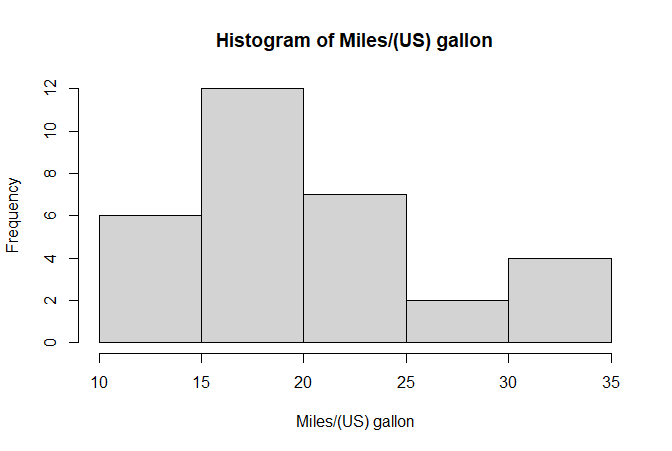

```r
invisible(wnl(mt2, hist(mpg))) # name label, not colname as title
```

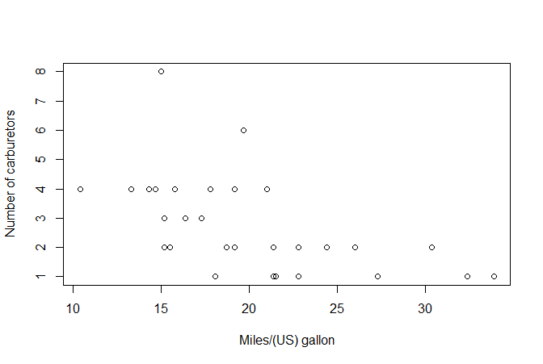

```r
invisible(wnl(mt2, plot(mpg, carb))) # name labels, not colnames, on axes
```

### Add and use variable VALUE labels

Let’s add VALUE labels.

```r
mt2 <- add_val_labs(
  data = mt2,
  vars = "am",
  vals = c(0, 1),
  labs = c("automatic", "manual")
)
### > Labeling variable --am--:
### >   var vals      labs
### > 1  am    0 automatic
### > 2  am    1    manual
### > 3  am   NA        NA

mt2 <- add_val_labs(
  data = mt2,
  vars = "carb",
  vals = c(1, 2, 3, 4, 6, 8),
  labs = c(
    "1-carb", "2-carbs",
    "3-carbs", "4-carbs",
    "6-carbs", "8-carbs"
  )
)
### > Labeling variable --carb--:
### >     var vals    labs
### > 4  carb    1  1-carb
### > 5  carb    2 2-carbs
### > 6  carb    3 3-carbs
### > 7  carb    4 4-carbs
### > 8  carb    6 6-carbs
### > 9  carb    8 8-carbs
### > 10 carb   NA      NA
```

The variable argument can be unquoted if we use `add_val1`. Note that the second argument to `add_val_labs` is vars, while second argument to `add_val1` is var.

```r
mt2 <- add_val1(
  data = mt2,
  var = cyl, ### note, "var," not "vars" arg
  vals = c(4, 6, 8),
  labs = c(
    "four-cyl",
    "six-cyl",
    "eight-cyl"
  )
)
### > Labeling variable --cyl--:
### >    var vals      labs
### > 11 cyl    4  four-cyl
### > 12 cyl    6   six-cyl
### > 13 cyl    8 eight-cyl
### > 14 cyl   NA        NA
```

### Add and NUMERICAL RANGE value labels

Now, let’s add numerical value range labels, using `add_quant_labs()`.

```r
# for "disp", add numerical range labels based on quantiles (here, quintiles)
mt2 <- add_quant_labs(data = mt2, vars = "disp", qtiles = 5)
### > Labeling variable --disp--:
### >     var  vals labs
### > 15 disp 120.1 q020
### > 16 disp   160 q040
### > 17 disp 275.8 q060
### > 18 disp   351 q080
### > 19 disp   472 q100
### > 20 disp    NA   NA

# for "mpg", add numerical range labels based on "pretty" cuts
# bound bins using range of "mpg" vals
mpg_bins <- pretty(range(mt2$mpg, na.rm = TRUE))
mpg_bins
### > [1] 10 15 20 25 30 35


mt2 <- add_quant_labs(
  data = mt2,
  vars = "mpg",
  vals = mpg_bins
) # assign labels using our "pretty" thresholds
### > Warning in add_quant_labs(data = mt2, vars = "mpg", vals = mpg_bins):
### >
### > Some of the supplied vals argument values are outside
### > the observed range of var --mpg-- values
### > Labeling variable --mpg--:
### >    var vals labs
### > 21 mpg   10 <=10
### > 22 mpg   15 <=15
### > 23 mpg   20 <=20
### > 24 mpg   25 <=25
### > 25 mpg   30 <=30
### > 26 mpg   35 <=35
### > 27 mpg   NA   NA

head(use_val_labs(mt2), 4)
### >                 mpg      cyl disp  hp drat    wt  qsec vs        am gear
### > Missing Car    <NA>     <NA> <NA>  NA   NA    NA    NA NA      <NA>   NA
### > Mazda RX4 Wag  <=25  six-cyl q040 110 3.90 2.875 17.02  0    manual    4
### > Datsun 710     <=25 four-cyl q020  93 3.85 2.320 18.61  1    manual    4
### > Hornet 4 Drive <=25  six-cyl q060 110 3.08 3.215 19.44  1 automatic    3
### >                   carb
### > Missing Car       <NA>
### > Mazda RX4 Wag  4-carbs
### > Datsun 710      1-carb
### > Hornet 4 Drive  1-carb
```

### Add MANY-TO-ONE VALUE Labels

Let’s demonstrate “m1” (“many to one”) value labels with the “gear” variable.

```r
mt2 <- add_m1_lab(
  data = mt2,
  vars = "gear",
  vals = 3,
  lab = "3"
)
### > Labeling variable --gear--:
### >     var vals labs
### > 28 gear    3    3
### > 29 gear    4    4
### > 30 gear    5    5
### > 31 gear   NA   NA

mt2 <- add_m1_lab(
  data = mt2,
  vars = "gear",
  vals = 4:5,
  lab = "4+"
)
### > Labeling variable --gear--:
### >     var vals labs
### > 21 gear    3    3
### > 22 gear    4   4+
### > 23 gear    5   4+
### > 24 gear   NA   NA
```

### Preserve and Restore Labels

Preserve label attributes.

```r
zlab.mt2 <- get_all_lab_atts(mt2)
```

Now, remove them.

```r
mt2 <- strip_labs(mt2)
get_all_lab_atts(mt2)
### > named list()
```

Now, restore them.

```r
mt2 <- add_lab_atts(mt2, zlab.mt2)
get_all_lab_atts(mt2)
### > $frame.lab
### > [1] "Data extracted from the 1974 MotorTrend US magazine, comprising fuel consumption and 10 aspects of automobiledesign and performance for 32 automobiles (1973–74 models). Source: Hendersonand Velleman (1981), Building multiple regression models interactively. Biometrics, 37, 391–411."
### >
### > $name.labs
### >                                        mpg
### >                        "Miles/(US) gallon"
### >                                        cyl
### >                      "Number of cylinders"
### >                                       disp
### >                    "Displacement (cu.in.)"
### >                                         hp
### >                         "Gross horsepower"
### >                                       drat
### >                          "Rear axle ratio"
### >                                         wt
### >                        "Weight (1000 lbs)"
### >                                       qsec
### >                            "1/4 mile time"
### >                                         vs
### >      "Engine (0 = V-shaped, 1 = straight)"
### >                                         am
### > "Transmission (0 = automatic, 1 = manual)"
### >                                       gear
### >                  "Number of forward gears"
### >                                       carb
### >                    "Number of carburetors"
### >
### > $val.labs.mpg
### >     10     15     20     25     30     35     NA
### > "<=10" "<=15" "<=20" "<=25" "<=30" "<=35"   "NA"
### >
### > $val.labs.cyl
### >           4           6           8          NA
### >  "four-cyl"   "six-cyl" "eight-cyl"        "NA"
### >
### > $val.labs.disp
### >  120.1    160  275.8    351    472     NA
### > "q020" "q040" "q060" "q080" "q100"   "NA"
### >
### > $val.labs.am
### >           0           1          NA
### > "automatic"    "manual"        "NA"
### >
### > $val.labs.gear
### >    3    4    5   NA
### >  "3" "4+" "4+" "NA"
### >
### > $val.labs.carb
### >         1         2         3         4         6         8        NA
### >  "1-carb" "2-carbs" "3-carbs" "4-carbs" "6-carbs" "8-carbs"      "NA"
```

### Add value labels with a |> pipe-based workflow

Let’s try a pipe-based, value-labeling flow with `add_val1()`

```r
mt_pipe <- mtcars |>
  add_val1(am,
    vals = c(0, 1),
    labs = c("automatic", "manual")
  ) |>
  add_val1(cyl,
    vals = c(4, 6, 8),
    labs = c("four-cyl", "six-cyl", "eight-cyl")
  ) |>
  add1m1(gear,
    vals = 3,
    lab = "3"
  ) |>
  add1m1(gear,
    vals = c(4, 5),
    lab = c("4+")
  ) |>
  add_val1(carb,
    vals = c(1, 2, 3, 4, 6, 8),
    labs = c(
      "1-carb", "2-carbs", "3-carbs",
      "4-carbs", "6-carbs", "8-carbs"
    )
  ) |>
  add_quant1(mpg,
    qtiles = 4
  )
### > Labeling variable --am--:
### >   var vals      labs
### > 1  am    0 automatic
### > 2  am    1    manual
### > 3  am   NA        NA
### > Labeling variable --cyl--:
### >   var vals      labs
### > 4 cyl    4  four-cyl
### > 5 cyl    6   six-cyl
### > 6 cyl    8 eight-cyl
### > 7 cyl   NA        NA
### > Labeling variable --gear--:
### >     var vals labs
### > 8  gear    3    3
### > 9  gear    4    4
### > 10 gear    5    5
### > 11 gear   NA   NA
### > Labeling variable --gear--:
### >     var vals labs
### > 8  gear    3    3
### > 9  gear    4   4+
### > 10 gear    5   4+
### > 11 gear   NA   NA
### > Labeling variable --carb--:
### >     var vals    labs
### > 12 carb    1  1-carb
### > 13 carb    2 2-carbs
### > 14 carb    3 3-carbs
### > 15 carb    4 4-carbs
### > 16 carb    6 6-carbs
### > 17 carb    8 8-carbs
### > 18 carb   NA      NA
### > Labeling variable --mpg--:
### >    var   vals labs
### > 19 mpg 15.425 q025
### > 20 mpg   19.2 q050
### > 21 mpg   22.8 q075
### > 22 mpg   33.9 q100
### > 23 mpg     NA   NA
```

Note, we could’ve used `add_val_labs()` (instead of `add_val1()`), `add_m1_lab()` (instead of `add1m1()`), and `add_quant_labs()` (instead of `add_quant1()`) in the foregoing pipe operations, but we’d have had to quote the variables names in the calls.

### Show Select Rows

```r
head(mt_pipe, 5) # Base R function utils::head()
### >                    mpg cyl disp  hp drat    wt  qsec vs am gear carb
### > Mazda RX4         21.0   6  160 110 3.90 2.620 16.46  0  1    4    4
### > Mazda RX4 Wag     21.0   6  160 110 3.90 2.875 17.02  0  1    4    4
### > Datsun 710        22.8   4  108  93 3.85 2.320 18.61  1  1    4    1
### > Hornet 4 Drive    21.4   6  258 110 3.08 3.215 19.44  1  0    3    1
### > Hornet Sportabout 18.7   8  360 175 3.15 3.440 17.02  0  0    3    2

headl(mt_pipe, 5) # labelr function headl() (note the "l")
### >                    mpg       cyl disp  hp drat    wt  qsec vs        am gear
### > Mazda RX4         q075   six-cyl  160 110 3.90 2.620 16.46  0    manual   4+
### > Mazda RX4 Wag     q075   six-cyl  160 110 3.90 2.875 17.02  0    manual   4+
### > Datsun 710        q075  four-cyl  108  93 3.85 2.320 18.61  1    manual   4+
### > Hornet 4 Drive    q075   six-cyl  258 110 3.08 3.215 19.44  1 automatic    3
### > Hornet Sportabout q050 eight-cyl  360 175 3.15 3.440 17.02  0 automatic    3
### >                      carb
### > Mazda RX4         4-carbs
### > Mazda RX4 Wag     4-carbs
### > Datsun 710         1-carb
### > Hornet 4 Drive     1-carb
### > Hornet Sportabout 2-carbs

tail(mt_pipe, 5) # Base R function utils::tail()
### >                 mpg cyl  disp  hp drat    wt qsec vs am gear carb
### > Lotus Europa   30.4   4  95.1 113 3.77 1.513 16.9  1  1    5    2
### > Ford Pantera L 15.8   8 351.0 264 4.22 3.170 14.5  0  1    5    4
### > Ferrari Dino   19.7   6 145.0 175 3.62 2.770 15.5  0  1    5    6
### > Maserati Bora  15.0   8 301.0 335 3.54 3.570 14.6  0  1    5    8
### > Volvo 142E     21.4   4 121.0 109 4.11 2.780 18.6  1  1    4    2

taill(mt_pipe, 5) # labelr function taill() (note the "l")
### >                 mpg       cyl  disp  hp drat    wt qsec vs     am gear    carb
### > Lotus Europa   q100  four-cyl  95.1 113 3.77 1.513 16.9  1 manual   4+ 2-carbs
### > Ford Pantera L q050 eight-cyl 351.0 264 4.22 3.170 14.5  0 manual   4+ 4-carbs
### > Ferrari Dino   q075   six-cyl 145.0 175 3.62 2.770 15.5  0 manual   4+ 6-carbs
### > Maserati Bora  q025 eight-cyl 301.0 335 3.54 3.570 14.6  0 manual   4+ 8-carbs
### > Volvo 142E     q075  four-cyl 121.0 109 4.11 2.780 18.6  1 manual   4+ 2-carbs

car::some(mt_pipe, 5) # car package function car::some()
### >                    mpg cyl  disp  hp drat    wt  qsec vs am gear carb
### > Hornet Sportabout 18.7   8 360.0 175 3.15 3.440 17.02  0  0    3    2
### > Merc 280          19.2   6 167.6 123 3.92 3.440 18.30  1  0    4    4
### > Merc 450SE        16.4   8 275.8 180 3.07 4.070 17.40  0  0    3    3
### > AMC Javelin       15.2   8 304.0 150 3.15 3.435 17.30  0  0    3    2
### > Fiat X1-9         27.3   4  79.0  66 4.08 1.935 18.90  1  1    4    1

somel(mt_pipe, 5, seed = 1837) # labelr function somel() (note the "l")
### >                 mpg       cyl  disp  hp drat    wt  qsec vs        am gear
### > AMC Javelin    q025 eight-cyl 304.0 150 3.15 3.435 17.30  0 automatic    3
### > Fiat X1-9      q100  four-cyl  79.0  66 4.08 1.935 18.90  1    manual   4+
### > Ford Pantera L q050 eight-cyl 351.0 264 4.22 3.170 14.50  0    manual   4+
### > Merc 230       q075  four-cyl 140.8  95 3.92 3.150 22.90  1 automatic   4+
### > Hornet 4 Drive q075   six-cyl 258.0 110 3.08 3.215 19.44  1 automatic    3
### >                   carb
### > AMC Javelin    2-carbs
### > Fiat X1-9       1-carb
### > Ford Pantera L 4-carbs
### > Merc 230       2-carbs
### > Hornet 4 Drive  1-carb
```

Note that `some()` and `somel()` will not return the same random rows.